# Data Visualization

Lecture 04

January 30, 2026

# Review

## EDA

- **EDA**: Understand structure of data while making as few assumptions as possible (e.g. look at the raw data, not “smoothed” versions).
- You might be asking the “right” questions but have the “wrong” data: be open-minded and rely on domain knowledge.
- Quantitative EDA can be a starting point, but EDA also requires visualization.

# Data Visualization

## Challenges for Effective Visualization

- Limits From Cognitive Processes
- No “Optimal” Visualization
- Temptation To Overload Figures
- Easy to “Lie” About The Data

## Further Challenges

Following Munzner (2014):

- Possible designs are a bad match with human perceptual and cognitive systems;
- Possible designs are a bad match with the intended task;
- Only a small number of possibilities are reasonable choices;
- “**Randomly choosing possibilities is a bad idea because the odds of finding a very good solution are very low**.”

## Remember: Data Never Speaks For Itself

Data must be understood in a particular context. You need to understand your data and what it says (or does not say!) based on your hypotheses.

- What question(s) does your data address?
- What transformations make the representation of the data as salient as possible?
- What scales or channels are most appropriate?

## Some Caveats

- There is no recipe to effective visualization. Everything depends on your data and the story you want to tell.
- This also means that defaults from data visualization packages are usually bad.
- Principles are largely based on Western (American/European) norms and may not translate perfectly.
- A lot of these guidelines are based on average outcomes, there is likely to be a lot of individual variation.

# Some Data Viz Principles

## Gestalt Principles

The Gestalt school of psychology identified several principles of perception.

Core idea: **Humans are very good at finding structure.**

As a result, you need to evaluate the totality of a visual field, not just each component.

## Gestalt Principles

- Proximity
- Similarity
- Connection
- Common Fate
- Continuity
- Closure

[figure not shown]

Illustration of Gestalt principles

Illustration of several Gestalt principles. Adapted from Healy (2018).

## Impact of Continuity

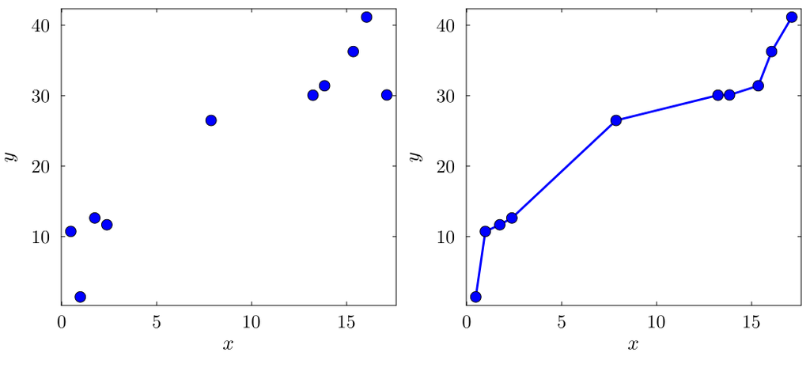

Figure 1: Illustrating impact of connected points.

```julia
# create trend for data
x = rand(Uniform(0, 20), 10)
y = 5 .+ 2 * x
# sample and add noise
ε = rand(Normal(0, 5), 10)
y .+= ε

p1 = scatter(x, y, xlabel=L"$x$", ylabel=L"$y$", color=:blue, markersize=8)
p2 = plot(sort(x), sort(y), xlabel=L"$x$", ylabel=L"$y$", color=:blue, marker=:circle, markersize=8)

plot(p1, p2, layout=(1,2), size=(1100, 500))
```

## Vertical Scales

- Worry about the vertical scale
  - Are you exaggerating small changes? Downplaying meaningful changes?
  - “Adjust vertical scale of data” to reflect meaningful changes and “Vertical scale should always include zero” are conflicting advice.

## Principle of Proportional Ink

**On the left**: 2014 quantity is **~1.1x** 2010 value, but due to vertical scale the 2014 bar uses **2.7x** the ink.

Can mislead viewers into thinking the difference is larger than it truly is!

[figure not shown]

Illustration of Non-Proportional Ink

Source: [Calling Bullshit](https://callingbullshit.org/tools/tools_proportional_ink.html)

## What Makes A Good Color Scheme?

- *Perceptually uniformity*: preserve a mapping between changes in perceived colors and changes in attribute values.
- *Color-blind safe!*

## Color Schemes

**Good news**: Most plotting libraries include a wide variety of perceptually uniform, color-blind safe color schemes.

**Bad news**: These are not usually the defaults (in particular, avoid “rainbow” color schemes).

Good site: [Paul Tol’s color schemes](https://sronpersonalpages.nl/~pault/).

## Sequential Color Schemes

Sequential schemes change in intensity from low to high as the value changes.

[figure not shown]

## Divergent Color Schemes

Divergent schemes intensify in two directions from a zero or mean value.

[figure not shown]

## Unordered Color Schemes

Unordered schemes are appropriate for categorical data.

[figure not shown]

## Avoid Using Two Vertical Axes

[figure not shown]

Two axis plot

Source: [Datawrapper.de](https://www.datawrapper.de/blog/dualaxis)

## Avoid Using Two Vertical Axes

[figure not shown]

Two axis plot

[figure not shown]

Illustration of how rescaling axes manipulates impression

Source: [Datawrapper.de](https://www.datawrapper.de/blog/dualaxis)

## Example: Spurious Correlations

[figure not shown]

Spurious Correlation 5901

Source: [Spurious Correlations](https://www.tylervigen.com/spurious/correlation/5901_annual-us-household-spending-on-fresh-fruits_correlates-with_canadian-national-railway-companys-stock-price-cni)

## Encode Information With Marks and Channels

**Marks**: Geometric primitives

- Points
- Segments
- Paths
- Polygons

**Channels**: Mark appearance

- Color (Hue/Saturation/Luminescence)
- Position (1D/2D/3D)
- Size (Length/Area/Volume)
- Angle

## Ordered vs. Categorical Attributes

The channels available depend on the type of attribute:

- **Ordered** attributes can be
  - *Ordinal*: Ranking, no meaning to distance;
  - *Quantitative*: Measure of magnitude which supports arithmetic comparison;
- **Categorical** attributes are unordered.

## Channel Effectiveness: Ordered Data

[figure not shown]

Channels for ordered data, arranged top-to-bottom from more to less effective (channels in the right column are less effective than those in the left). Modified from Healy (2018) after Munzner (2014).

## Channel Effectiveness: Categorical Data

[figure not shown]

Channels for categorical data, arranged top-to-bottom from more to less effective. Modified from Healy (2018) after Munzer (2014).

## Preattentive Popout

Try to make your key features “pop out” to the viewer during the pre-attentive scan.

Searching for the blue circle becomes harder. Adapted from Healy (2018).

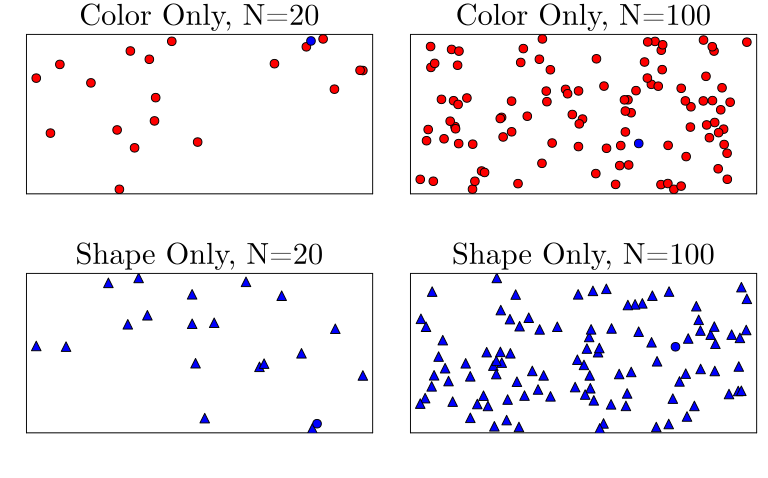

```julia
npt = 20
dist = Distributions.Product(Uniform.([0, 0], [1, 1]))
pts = Tuple.(eachcol(rand(dist, npt)))
blueidx = rand(1:npt)
p1 = scatter(pts[1:end .!= blueidx], color=:red, xticks=:false, yticks=:false, legend=:false, markersize=5, title="Color Only, N=20", framestyle=:box)
scatter!(p1, pts[blueidx, :], color=:blue, markersize=5)

npt = 100
pts = Tuple.(eachcol(rand(dist, npt)))
blueidx = rand(1:npt)
p2 = scatter(pts[1:end .!= blueidx], color=:red, xticks=:false, yticks=:false, legend=:false, markersize=5, title="Color Only, N=100", framestyle=:box)
scatter!(p2, pts[blueidx, :], color=:blue, markersize=5)

npt = 20
pts = Tuple.(eachcol(rand(dist, npt)))
blueidx = rand(1:npt)
p3 = scatter(pts[1:end .!= blueidx], color=:blue, markershape=:utriangle, xticks=:false, yticks=:false, legend=:false, markersize=5, title="Shape Only, N=20", framestyle=:box)
scatter!(p3, pts[blueidx, :], color=:blue, markersize=5, markershape=:circle)

npt = 100
pts = Tuple.(eachcol(rand(dist, npt)))
blueidx = rand(1:npt)
p4 = scatter(pts[1:end .!= blueidx], color=:blue, markershape=:utriangle, xticks=:false, yticks=:false, legend=:false, markersize=5, title="Shape Only, N=100", framestyle=:box)
scatter!(p4, pts[blueidx, :], color=:blue, markersize=5, markershape=:circle)

plot(p1, p2, p3, p4, layout=(2, 2), size=(800, 500))
```

# Visualization Examples

## Thoughts On This Plot?

[figure not shown]

First Street Foundation Return Period Trends

Source: Shu et al. (2023)

## How About This One?

[figure not shown]

Trump Polling Average vs. Employment in Swing States

Source: [Joe Weisenthal](https://twitter.com/TheStalwart/status/1309582619290595328)

## Or This One?

[figure not shown]

Impacts of Climate Mitigation on Air Pollution

Source: Huang et al. (2023)

## Or…

[figure not shown]

Relationship Between Climate Variables

Source: Errickson et al. (2021)

## Last One!

[figure not shown]

Modeled Flood Risk vs. Perception

Source: Bakkensen & Barrage (2022)

# Key Points

## Data Visualization

- No “cookbook”: be thoughtful and honest with your data.
- Defaults from software packages (scales, colors, etc.) are usually bad.
- Think carefully about if you’re creating artifacts which might mislead others, even if unintentional.

# Upcoming Schedule

## Next Classes

**Next Week**: Probability Models and Linear Regression

## Assessments

**Homework 1** Due Friday, 2/6.

**Exercises**: This week’s involves some simple computations.

**Reading**: Franconeri et al (2024)

**Quiz 1**: Friday, 2/13.

# References

## References (Scroll for Full List)

Bakkensen, L. A., & Barrage, L. (2022). Going Underwater? Flood Risk Belief Heterogeneity and Coastal Home Price Dynamics. *Rev. Financ. Stud.*, *35*, 3666–3709. https://doi.org/10.1093/rfs/hhab122

Errickson, F. C., Keller, K., Collins, W. D., Srikrishnan, V., & Anthoff, D. (2021). Equity is more important for the social cost of methane than climate uncertainty. *Nature*, *592*, 564–570. https://doi.org/10.1038/s41586-021-03386-6

Healy, K. (2018). *Data visualization: A practical introduction*. Princeton University Press.

Huang, X., Srikrishnan, V., Lamontagne, J., Keller, K., & Peng, W. (2023). Effects of global climate mitigation on regional air quality and health. *Nature Sustainability*, 1–13. https://doi.org/10.1038/s41893-023-01133-5

Munzner, T. (2014). *Visualization analysis and design*. CRC Press.

Shu, E., Hauer, M., & Porter, J. (2023, November). *Future population exposure to flood risk: A decomposition approach across Shared-Socioeconomic pathways (SSPs)*. *Research Square*. https://doi.org/10.21203/rs.3.rs-3628132/v1